# Final Project

### Math 248 Final Project (2023); Building a predictive machine learning model to estimate image locations

#### Why? Big picture:

1. Use images to track down criminals
2. Disaster response/affected area identification
3. Travel/tourism; identifying landmarks, monuments, or historical sites from images
4. Historical research/archaeological identification
5. Military strategy

#### Analytical approach to location identification?

Unable to obtain an exact solution through analytical methods as there are many variables involved.

But, general digital image processing can be done through Singular Value Decomposition, Fourier analysis, or other analytical methods which can extract/classify important features from images.

These can then be used to inform a model of some of the subtle but complex features of an image that can help to make an accurate prediction possible.

#### Numerical approach to location identification?

Machine learning model trained on large datasets of geotagged images. More complex models could even take advantage of feature-based matching and begin to classify things like cars, trees, plants, architecture, etc. and then give us a precise area in which the picture could have been taken.However, this is also a mixed approach as it requires multiple analytical functions that allow the model to interpret input data and return a meaningful output

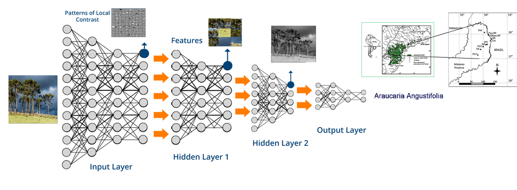

Requires extremely high computing capabilities, memory, and massive datasets along with very complex, finely tuned ML models.

### Combination of Analytical, Numerical, and Programmatic methods in the current project:

#### Data collection

In order to collect a large set of geotagged images I used an online image-based location guessing game called Geoguessr.

[figure not shown]

Then, using pyautogui and a script that captures the coordinates of each location, data collection was able to be automated through a program.

Each round was screenshotted and saved along with the corresponding coordinates and then the program would move on to the next round.

```python
import time
import os
import pyautogui
import pyperclip
import webbrowser
import numpy as np
import cv2


ROUNDS_PER_GAME = 5
NUM_GAMES = 50


OUTPUT_DIR = r"C:\Users\ttdog\OneDrive\Desktop\Training Data\ScrapScreenshots"
GEOGUESSR_URL = "https://www.geoguessr.com/maps/59a1514f17631e74145b6f47/play"


LOAD_TIME = 3
PROCESS_TIME = 2
WAIT_TIME = 2

webbrowser.open_new_tab(GEOGUESSR_URL)


time.sleep(LOAD_TIME)
time.sleep(1)


rounds_played = 0

games_played = 0


while games_played < NUM_GAMES:
    while rounds_played < ROUNDS_PER_GAME:
        time.sleep(LOAD_TIME)
        screenshot = pyautogui.screenshot()

        output_path = os.path.join(OUTPUT_DIR, f"game_{games_played}_round_{rounds_played}.png")
        screenshot.save(output_path)

        pyautogui.hotkey("ctrl", "r")
        time.sleep(LOAD_TIME)

        pyautogui.hotkey("shift", "alt", "g")

        time.sleep(1) #e

        pyautogui.hotkey("ctrl", "l")

        time.sleep(.3) #e

        pyautogui.hotkey("ctrl", "c")

        time.sleep(.3) #e

        pyautogui.hotkey("ctrl", "w")


        url = pyperclip.paste()

        coordinates = url.split("/")[-1]

        latitude, longitude = coordinates.split(",")

        #print(f"Latitude: {latitude}, Longitude: {longitude}")

        # Open the file in write mode
        with open(r"C:\Users\ttdog\OneDrive\Desktop\Training Data\Coordinates\ScrapCoordinates.txt", "a") as f:
            f.write(f"Latitude: {latitude}, Longitude: {longitude}\n")




        # Make a random guess
        time.sleep(1)
        pyautogui.click(2000,1500)
        time.sleep(1)
        #pyautogui.click(1800,900)

        import random
        import pyautogui

        coords_list = [(1400,800), (1420,900), (1590,900), (1579,777), (1620,790),
                      (1785,860), (1800,900), (1890,988), (1876,823), (1637,970),
                      (1440,985), (1609,734), (1778,772)]

        # Randomly select one of the coordinates from the list
        x, y = random.choice(coords_list)

        # Click on the selected coordinate
        pyautogui.click(x, y)





        time.sleep(1)
        pyautogui.click(1600,1550)



        time.sleep(2)
        pyautogui.press('space')

        time.sleep(PROCESS_TIME)

        pyautogui.keyDown("space")
        pyautogui.keyUp("space")

        rounds_played += 1

        time.sleep(WAIT_TIME)

    pyautogui.keyDown("space")
    pyautogui.keyUp("space")

    rounds_played = 0

    games_played += 1

    time.sleep(WAIT_TIME)
```

[figure not shown]

#### Feature collection

Analytical approach: Images could have their singular value decomposition matrix computed in order to reduce the size of images while retaining much of the information.

```
Type of the image :  <class 'numpy.ndarray'>
Shape of the image : (1440, 2412, 4)
Image Height 1440
Image Width 2412
Dimension of Image 3
```

[figure not shown]

```python
import matplotlib.pyplot as plt
# Let's read the image file. It will be saved as 3 dimensional array, one layer for each channel.
picture = plt.imread("geoguessr.png")
# Let's see how python saves this image file
print('Type of the image : ' , type(picture))
print(f'Shape of the image : {picture.shape}')
print(f'Image Height {picture.shape[0]}')
print(f'Image Width {picture.shape[1]}')
print(f'Dimension of Image {picture.ndim}')
# Let's display the image
plt.imshow(picture)
```

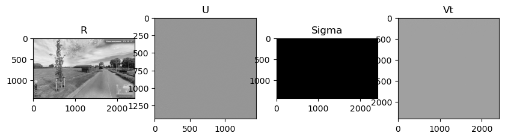

```python
import matplotlib.cm as cm
R=picture[:,:,0] # red channel

# Choose a channel and perform singular value decomposition. Do not print the matrices
# since they are very big, just show their image
# Find the singular value decomposition of R
U,sigma,Vt=np.linalg.svd(R)
# store sigma in a diagonal matrix that has the same shape as R
Sigma=np.zeros(R.shape) # Sigma has the same shape as R
m=np.amin(R.shape) # pick the smaller number between the number of rows and columns
Sigma[0:m,0:m]=np.diag(sigma) # place the singular values on the diagnal of Sigma
# Let's visualize the above product
# split the figure into 4 subplots
fig, subs=plt.subplots(nrows = 1, ncols=4, figsize=(10,5))
subs[0].imshow(R,cmap=cm.Greys_r)
subs[0].set_title('R')
subs[1].imshow(U,cmap=cm.Greys_r)
subs[1].set_title('U')
subs[2].imshow(Sigma,cmap=cm.Greys_r)
subs[2].set_title('Sigma')
subs[3].imshow(Vt,cmap=cm.Greys_r)
subs[3].set_title('Vt')
```

Then we could save each of these compressed matrix representation for each image and have them as input into specific nodes, however, this would have greatly increased the computational complexity required in training the model. Adding any more layers reliably caused training to take too long or it just drained memory and killed the kernel.

Also computing the SVD matrix for each image in the dataset wasn't very appealing.

So instead just the raw pixel values were fed into the models.

#### Model training

Picking the best model architecture is largely a process of trial-and-error along with taking into account what features would work best for that specific project and ones computing capabilities.

##### Architecture decisions

A sigmoid activation function gives an output between 0 and 1 for all x and is defined by: $$S(x) = \frac{1}{1+e^{-x}}$$

Optimizer - Which inputs to consider and how to iteratively minimize loss over the models training. The Adam optimization algorithm was used in each model.

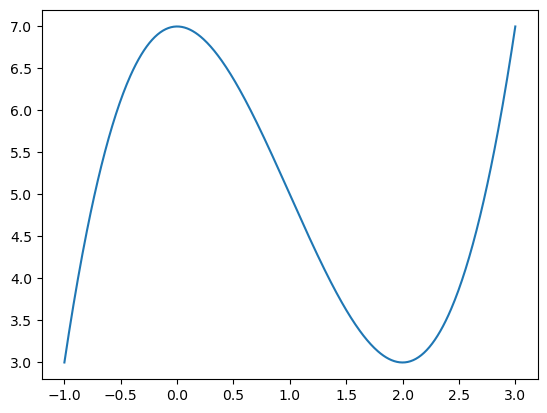

```python
adam = lambda x: (x ** 3)-(3 *(x ** 2))+7
x = np.linspace(-1,3,500)

plt.plot(x,adam(x))
plt.show()
```

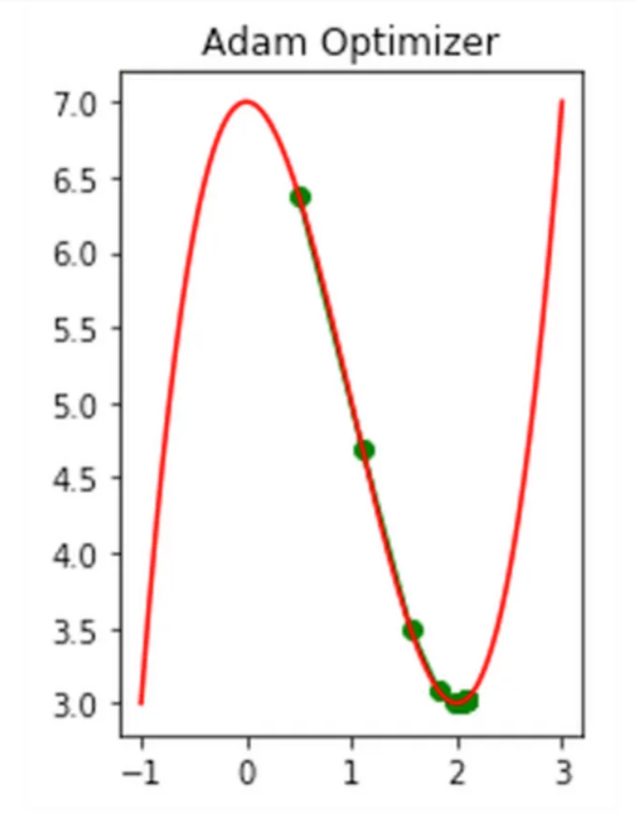

```python
import sympy as sp
function = lambda x: (x**3) - (3 *(x ** 2))+7


#def adam_optimizer(x_new, x_prev, precision, l_r, beta1, beta2, epsilon):
def adam_optimizer(x_new=0.5, x_prev=0, precision=0.001, l_r=0.6, beta1=0.9,beta2= 0.99,epsilon= 10**-8):

    x_list, y_list = [x_new], [function(x_new)]

    vd_x = 0
    sd_x = 0

    t=1

    while abs(x_new - x_prev) > precision:

        x_prev = x_new

        d_x = -sp.diff(x_prev)

        vd_x = beta1 * vd_x + ((1-beta1) * d_x)

        sd_x = beta2 * sd_x + ((1-beta2) * np.square(d_x))

        vd_x = vd_x / (1-(beta1)**t)
        sd_x = sd_x / (1-(beta2)**t)

        nd_x = vd_x / np.sqrt(sd_x + epsilon)

        x_new = x_prev + (l_r * nd_x)

        x_list.append(x_new)

        y_list.append(function(x_new))

        t+=1

adam_optimizer()
print("Local minimum occurs at: "+ str(x_new))
print("Number of steps: " + str(len(x_list)))

plt.subplot(1,2,2)
plt.scatter(x_list, y_list, c="g")
plt.plot(x_list,y_list, c="g")
plt.plot(x,function(x), c="r")
plt.title("Adam Optimizer")
plt.show()

plt.subplot(1,2,1)
plt.scatter(x_list,y_list,c="g")
plt.plot(x_list,y_list,c="g")
plt.plot(x,function(x),c="r")
plt.xlim([1.0,2.1])
plt.title("Zoomed in Adam to Key Area")
plt.show()
```

Takes an initial x value and iteratively updates it based on the Adam optimization algorithm until the minimum x value that satisfies the function is reached.

### Model 1

```python
import tensorflow as tf
import numpy as np
from tensorflow.keras.layers import Dense, Flatten, Conv2D, MaxPooling2D

reducedheight=624
reducedwidth=416
reduced2height=312
reduced2width=208

input_layer = tf.keras.layers.Input(shape=(reduced2height, reduced2width, 3))
x = tf.keras.layers.Conv2D(32, (3, 3), activation='relu')(input_layer)
x = tf.keras.layers.MaxPooling2D((2, 2))(x)
x = tf.keras.layers.Flatten()(x)
x = tf.keras.layers.Dense(2, activation='sigmoid')(x)
output_layer = x

model = tf.keras.models.Model(inputs=input_layer, outputs=output_layer)
model.compile(optimizer='adam', loss='mean_squared_error')

# Paths
images_folder = r"C:\Users\ttdog\OneDrive\Desktop\Training Data\2ReducedScreenshots4"
coordinates_file = r"C:\Users\ttdog\OneDrive\Desktop\Training Data\Coordinates\Coordinates4.txt"

# Lists for images & coordinates
X_train = []
y_train = []

# Loop through coordinates file and load images and coordinates
with open(coordinates_file, 'r') as f:
    for i, line in enumerate(f):
        lat, lon = map(float, line.split(','))
        y_train.append([lat, lon])
        img_path = f"{images_folder}/{i+1}.png"
        img = tf.keras.preprocessing.image.load_img(img_path, target_size=(reduced2height, reduced2width))
        img_arr = tf.keras.preprocessing.image.img_to_array(img)
        X_train.append(img_arr)

y_train = np.array(y_train)
X_train = np.array(X_train) / 255.0

# Training
model.fit(X_train, y_train, epochs=150, batch_size=106)

# Save
model.save('model1.h5')
```

### Model 2

```python
import tensorflow as tf
import numpy as np
from tensorflow.keras.layers import Dense, Flatten, Conv2D, MaxPooling2D

reducedheight=624
reducedwidth=416

input_layer = tf.keras.layers.Input(shape=(reducedheight, reducedwidth, 3))
x = tf.keras.layers.Conv2D(32, (3, 3), activation='relu')(input_layer)
x = tf.keras.layers.MaxPooling2D((2, 2))(x)
x = tf.keras.layers.Flatten()(x)
x = tf.keras.layers.Dense(2, activation='linear')(x)
output_layer = x

model = tf.keras.models.Model(inputs=input_layer, outputs=output_layer)
model.compile(optimizer='adam', loss='mean_absolute_error')

# set the path to the folder containing the images
images_folder = r"C:\Users\ttdog\OneDrive\Desktop\Training Data\ReducedScreenshots4"

# set the path to the coordinates file
coordinates_file = r"C:\Users\ttdog\OneDrive\Desktop\Training Data\Coordinates\Coordinates4.txt"

# initialize lists to store the image data and the corresponding coordinates
X_train = []
y_train = []

# loop through the coordinates file and load the images and coordinates
with open(coordinates_file, 'r') as f:
    for i, line in enumerate(f):
        lat, lon = map(float, line.split(','))
        y_train.append([lat, lon])
        img_path = f"{images_folder}/{i+1}.png"
        img = tf.keras.preprocessing.image.load_img(img_path, target_size=(reducedheight, reducedwidth))
        img_arr = tf.keras.preprocessing.image.img_to_array(img)
        X_train.append(img_arr)

y_train = np.array(y_train)
X_train = np.array(X_train) / 255.0

# Train your model
model.fit(X_train, y_train, epochs=10, batch_size=106)

# Save your trained model
model.save('secondmodel.h5')
```

```python
import tensorflow as tf
import numpy as np
from tensorflow.keras.layers import Dense, Flatten, Conv2D, MaxPooling2D

reducedheight=624
reducedwidth=416
reduced2height=312
reduced2width=208

input_layer = tf.keras.layers.Input(shape=(reduced2height, reduced2width, 3))
x = tf.keras.layers.Conv2D(32, (3, 3), activation='relu')(input_layer)
x = tf.keras.layers.MaxPooling2D((2, 2))(x)
x = tf.keras.layers.Flatten()(x)
x = tf.keras.layers.Dense(2, activation='linear')(x)
output_layer = x

model = tf.keras.models.Model(inputs=input_layer, outputs=output_layer)
model.compile(optimizer='adam', loss='mean_absolute_error')


images_folder = r"C:\Users\ttdog\OneDrive\Desktop\Training Data\2ReducedScreenshots4"
coordinates_file = r"C:\Users\ttdog\OneDrive\Desktop\Training Data\Coordinates\Coordinates4.txt"


X_train = []
y_train = []


with open(coordinates_file, 'r') as f:
    for i, line in enumerate(f):
        lat, lon = map(float, line.split(','))
        y_train.append([lat, lon])
        img_path = f"{images_folder}/{i+1}.png"
        img = tf.keras.preprocessing.image.load_img(img_path, target_size=(reduced2height, reduced2width))
        img_arr = tf.keras.preprocessing.image.img_to_array(img)
        X_train.append(img_arr)

y_train = np.array(y_train)
X_train = np.array(X_train) / 255.0


model.fit(X_train, y_train, epochs=250, batch_size=106)


model.save('9bmodel.h5')
```

### Testing how the model does

```python
import tensorflow as tf
import numpy as np
from tensorflow.keras.layers import Dense, Flatten, Conv2D, MaxPooling2D

# Load the trained model
model = tf.keras.models.load_model('9bmodel.h5')
norm=120
images_folder = r"C:\Users\ttdog\OneDrive\Desktop\Training Data\Model9ScreenshotsValidation"
X_test = []
for i in range(1, 6):
    img_path = f"{images_folder}/{i}.png"
    img = tf.keras.preprocessing.image.load_img(img_path, target_size=(312,208))
    img_arr = tf.keras.preprocessing.image.img_to_array(img)
    X_test.append(img_arr)
X_test = np.array(X_test)

# Predictions on the new data
y_pred = model.predict(X_test)/norm

# Predicted coordinates
predictions=print(y_pred[0:5])
predictions
```

```
[[ 48.1873    83.85427 ]
 [ 15.641254 -92.640236]
 [ 10.250204  29.397371]
 [ 71.2296    42.37426 ]
 [ -9.368075  61.64105 ]]
```

```python
import folium

def plot_coordinates_on_map(file_location, additional_coordinates=None):
    # Load coordinates from file
    coordinates = []
    with open(file_location, 'r') as f:
        for line in f:
            lat, lon = map(float, line.split(','))
            coordinates.append((lat, lon))

    # Create map centered on the first coordinate
    map_center = coordinates[0]
    my_map = folium.Map(location=map_center, zoom_start=6)

    # Add markers for each coordinate
    for i, coord in enumerate(coordinates):
        folium.Marker(location=coord, icon=None).add_to(my_map)
        folium.Marker(
            location=coord,
            icon=None,
            # Display the point number as a text label
            popup=str(i),
            # Add a text label offset to make it visible
            tooltip=f'Point {i}',
            ).add_to(my_map)

        # Add a dotted line between the corresponding coordinates from both lists
        if additional_coordinates and i < len(additional_coordinates):
            folium.PolyLine([coord, additional_coordinates[i]], color="red", dash_array='5').add_to(my_map)

    # Add markers for guess
    if additional_coordinates:
        for i, coord in enumerate(additional_coordinates):
            folium.Marker(location=coord, icon=folium.Icon(color='red')).add_to(my_map)
            folium.Marker(
                location=coord,
                icon=None).add_to(my_map)

    return my_map

file_location = r"C:\Users\ttdog\OneDrive\Desktop\Training Data\Coordinates\CoordinatesValidation.txt"
additional_coordinates = [[48.1873, 83.85427], [15.641254, -92.640236], [10.250204, 29.397371], [71.2296, 42.37426], [-9.368075, 61.64105]]
my_map = plot_coordinates_on_map(file_location, additional_coordinates)
my_map
```

Make this Notebook Trusted to load map: File -> Trust Notebook

[interactive chart not shown]

### What limited these models from accurate predictions?

##### Lack of compute power

1. Data collection involving frequent crashes--> Extremely small dataset(106 image/coordinate pairs)
2. Simple architecture/low number of nodes in the model--> Not effectively capturing important features

##### Lack of understanding of complexities of network architecture--> Slow improvement, underfitting, overfitting, etc.

### Could this actually work?

One approach:

1. Locations/images classified by country instead of coordinates

[figure not shown]

[figure not shown]

#### Over 50,000 training images

Performs better than the average person- able to guess the correct country 50% of the time